# TP 2 : Analyse préliminaire du jeu de données Titanic

Auteur·rice

HAMLIL Mohamed

Date de publication

2025

# Introduction

En TP nous travaillerons principalement avec le jeu de données `titanic`. Notre but sera de prédire la survie des passagers au naufrage du Titanic.

**NoteObjectif**

Préparer les données (Data Cleaning) et explorer les relations entre les variables (Data Exploration) avant la modélisation.

## 1. Jeu de données

### 1.1. Charger le jeu de données

**Format du fichier :** `.csv` (Comma Separated Values).

```r
# Chargement des librairies
library(dplyr)
library(ggplot2)
library(reshape2)
library(gridExtra)

# Chargement des données
# On utilise stringsAsFactors = FALSE pour garder la main sur les types
data = read.csv("../titanic.csv", stringsAsFactors = FALSE)
```

### 1.2. Caractéristiques du jeu de données

```r
dim(data)
```

```
[1] 876   8
```

Le jeu de données contient **876 individus** et **8 variables**.

### 1.3. Variables

```r
colnames(data)
```

```
[1] "PassengerId" "Survived"    "Pclass"      "Sex"         "Age"
[6] "SibSp"       "Parch"       "Fare"
```

**Types de données attendus :**

```r
str(data)
```

```
'data.frame':   876 obs. of  8 variables:
 $ PassengerId: int  1 2 3 4 5 6 7 8 9 10 ...
 $ Survived   : int  0 1 1 1 0 0 0 0 1 1 ...
 $ Pclass     : int  3 1 3 1 3 3 1 3 3 2 ...
 $ Sex        : chr  "male" "female" "female" "female" ...
 $ Age        : num  22 38 26 35 35 NA 54 2 27 14 ...
 $ SibSp      : int  1 1 0 1 0 0 0 3 0 1 ...
 $ Parch      : int  0 0 0 0 0 0 0 1 2 0 ...
 $ Fare       : num  7.25 71.28 7.92 53.1 8.05 ...
```

### 1.4. Target

La variable cible est **`Survived`**. Elle est initialement codée comme un entier (`int`).

**AstuceBonnes pratiques**

Il est préférable de convertir la target en **facteur** avec des labels explicites pour faciliter la lecture des graphiques et des résultats de modèles.

```r
target = factor(data$Survived, labels = c("Décédé", "Survivant"))
data$Survived = as.factor(data$Survived)
```

### 1.5. Transformation de variables (Feature Engineering)

Nous créons de nouvelles variables pour mieux capturer l’information contenue dans les données brutes.

1. **Taille de la famille (`Fam`)** : Somme des conjoints, frères, sœurs, parents et enfants.
2. **Indicateur de famille (`withFam`)** : Binaire, pour savoir si la personne est seule ou accompagnée.

```r
data$Fam = data$Parch + data$SibSp
data$withFam = as.factor(ifelse(data$Fam > 0, 1, 0))
```

3. **Catégories d’âge (`Age_cat`)** : L’âge a souvent un effet non linéaire (les enfants sont sauvés en priorité).

```r
# Gestion de la valeur max pour inclure tout le monde
max_age = max(data$Age, na.rm = TRUE)

data$Age_cat = cut(data$Age,
                   breaks = c(0, 13, 18, 60, max_age + 1),
                   labels = c("Enfant", "Adolescent", "Adulte", "Senior"),
                   right = FALSE)
```

**AvertissementAttention**

La variable `Age` contient des valeurs manquantes (`NA`). Par conséquent, `Age_cat` contiendra aussi des `NA` pour ces individus.

### 1.6. Sélection des variables prédictives

Nous écartons les identifiants et nous assurons que les variables qualitatives sont bien typées.

```r
# Typage correct
data$Pclass = as.factor(data$Pclass)
data$Sex    = as.factor(data$Sex)
if("Embarked" %in% colnames(data)) data$Embarked = as.factor(data$Embarked)

# Séparation
qualitative_vars  = data %>% select(Age_cat, Pclass, Sex, withFam)
quantitative_vars = data %>% select(Age, SibSp, Parch, Fam, Fare)
```

## 2. Analyse univariée

### 2.1. Statistiques descriptives

#### Variables quantitatives

```r
summary(quantitative_vars)
```

```
      Age            SibSp           Parch             Fam
 Min.   : 0.42   Min.   :0.000   Min.   :0.0000   Min.   : 0.0000
 1st Qu.:20.00   1st Qu.:0.000   1st Qu.:0.0000   1st Qu.: 0.0000
 Median :28.00   Median :0.000   Median :0.0000   Median : 0.0000
 Mean   :29.65   Mean   :0.532   Mean   :0.3881   Mean   : 0.9201
 3rd Qu.:38.00   3rd Qu.:1.000   3rd Qu.:0.0000   3rd Qu.: 1.0000
 Max.   :80.00   Max.   :8.000   Max.   :6.0000   Max.   :10.0000
 NA's   :169
      Fare
 Min.   :  4.013
 1st Qu.:  7.925
 Median : 14.500
 Mean   : 32.756
 3rd Qu.: 31.275
 Max.   :512.329
```

**Observations :**

- `Age` : Environ 20% de données manquantes.
- `Fare` : Très dispersée (Moyenne = 32, Max = 512). Distribution probablement très asymétrique.

#### Variables qualitatives

```r
summary(qualitative_vars)
```

```
       Age_cat    Pclass      Sex      withFam
 Enfant    : 69   1:211         :  2   0:522
 Adolescent: 44   2:178   female:314   1:354
 Adulte    :568   3:487   male  :560
 Senior    : 26
 NA's      :169
```

**ImportantNettoyage des chaînes vides**

Parfois, les données manquantes dans les fichiers CSV sont encodées par du vide `""` au lieu de `NA`. Il faut les corriger.

```r
# Exemple de correction si nécessaire (notamment pour Embarked)
# data$Embarked[data$Embarked == ""] <- NA
# data$Embarked <- droplevels(data$Embarked)
```

#### Target

```r
table(target)
```

```
target
   Décédé Survivant
      535       341
```

```r
prop.table(table(target))
```

```
target
   Décédé Survivant
0.6107306 0.3892694
```

Environ **38%** de survie. Les classes sont déséquilibrées, mais c’est gérable.

### 2.2. Analyse graphique

#### Variables quantitatives (Histogrammes)

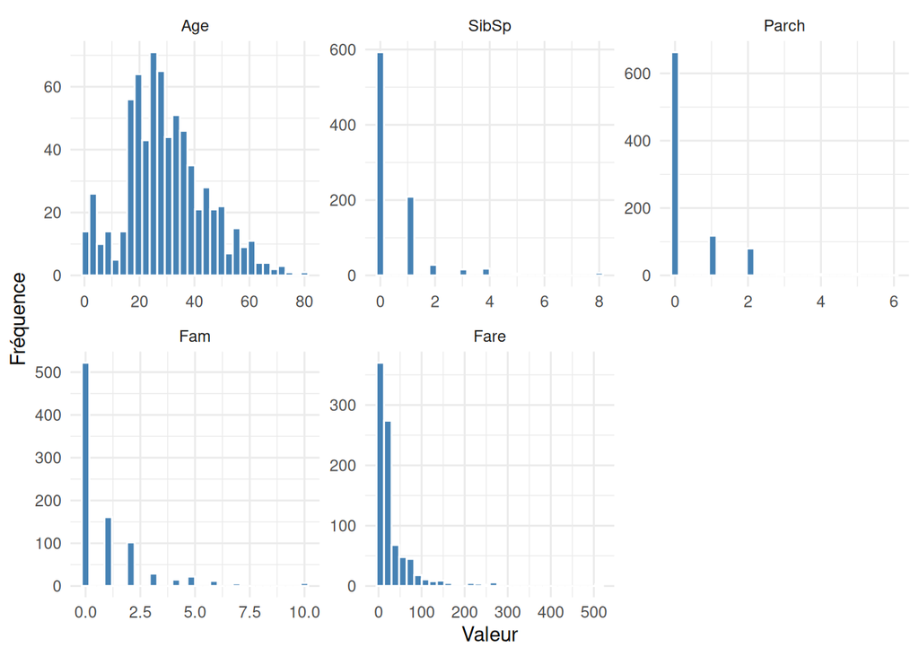

Distribution des variables quantitatives

```r
# Transformation en format long pour ggplot
quant_long = melt(quantitative_vars)

ggplot(quant_long, aes(x = value)) +
  geom_histogram(bins = 30, fill = "steelblue", color = "white") +
  facet_wrap(~variable, scales = "free") +
  theme_minimal() +
  labs(x = "Valeur", y = "Fréquence")
```

**Remarque :** Les distributions ne sont pas gaussiennes (normales).

- **Problème pour Naive Bayes :** Ce modèle suppose souvent la normalité des variables continues.
- **Solutions :** Transformation logarithmique (`log(x+1)`) ou discrétisation.

#### Variables qualitatives (Barplots)

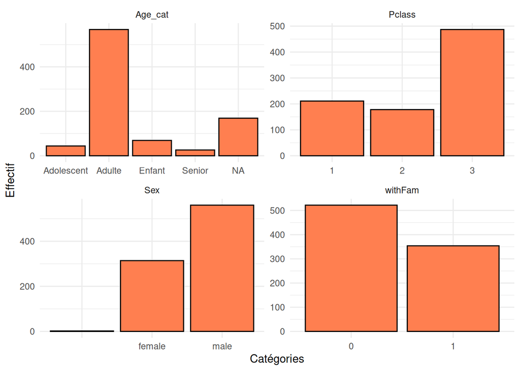

Distribution des variables qualitatives

```r
qual_long = melt(qualitative_vars, id.vars = NULL)

ggplot(qual_long, aes(x = value)) +
  geom_bar(fill = "coral", color = "black") +
  facet_wrap(~variable, scales = "free") +
  theme_minimal() +
  labs(x = "Catégories", y = "Effectif")
```

## 3. Analyse multivariée

### 3.1. Corrélations entre variables quantitatives

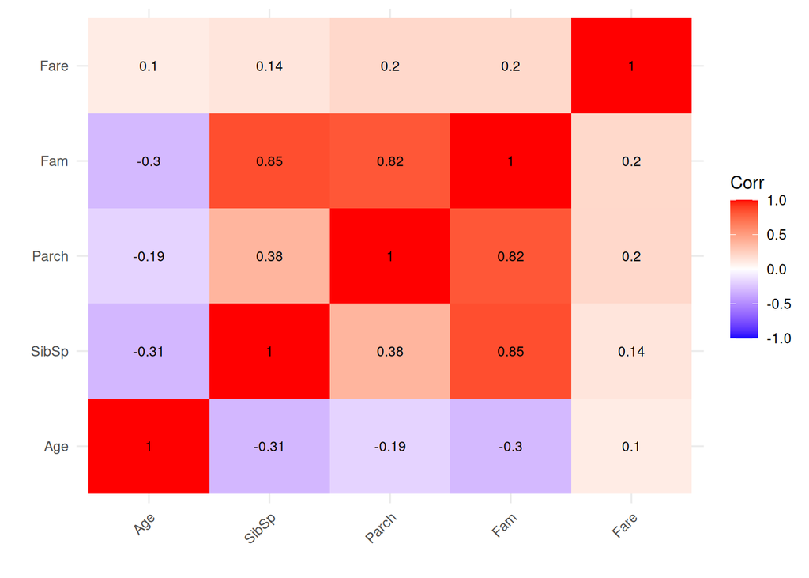

Matrice de corrélation

```r
cor_mat = cor(quantitative_vars, use = "complete.obs")
melted_cor_mat = melt(cor_mat)

ggplot(data = melted_cor_mat, aes(x = Var1, y = Var2, fill = value)) +
  geom_tile() +
  scale_fill_gradient2(low = "blue", mid = "white", high = "red", limit = c(-1,1)) +
  geom_text(aes(label = round(value, 2)), size = 3) +
  theme_minimal() +
  theme(axis.text.x = element_text(angle = 45, hjust = 1)) +
  labs(x = "", y = "", fill = "Corr")
```

**Multicolinéarité :** Forte corrélation entre `Fam`, `SibSp` et `Parch`. C’est attendu car `Fam = SibSp + Parch`. Il faudra éviter de mettre toutes ces variables ensemble dans certains modèles (ex: régression logistique) pour éviter la redondance.

### 3.2. Variables quantitatives vs Target

On utilise des **boxplots** pour voir si la distribution d’une variable change selon la survie.

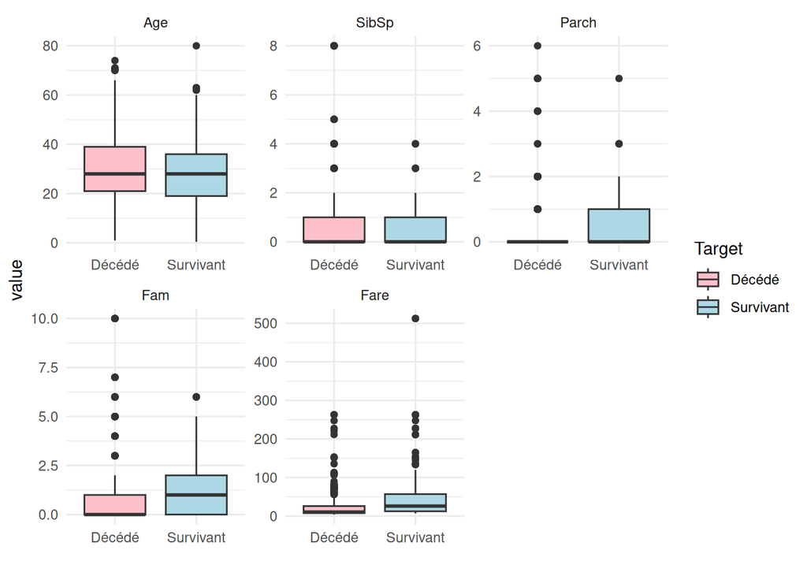

Impact des variables quantitatives sur la survie

```r
plot_data = cbind(quantitative_vars, Target = target)
plot_data_long = melt(plot_data, id.vars = "Target")

ggplot(plot_data_long, aes(x = Target, y = value, fill = Target)) +
  geom_boxplot() +
  facet_wrap(~variable, scales = "free") +
  scale_fill_manual(values = c("pink", "lightblue")) +
  theme_minimal() +
  labs(x = "")
```

### 3.3. Variables qualitatives vs Target

Nous comparons les **proportions** (fill) pour neutraliser l’effet d’effectif total.

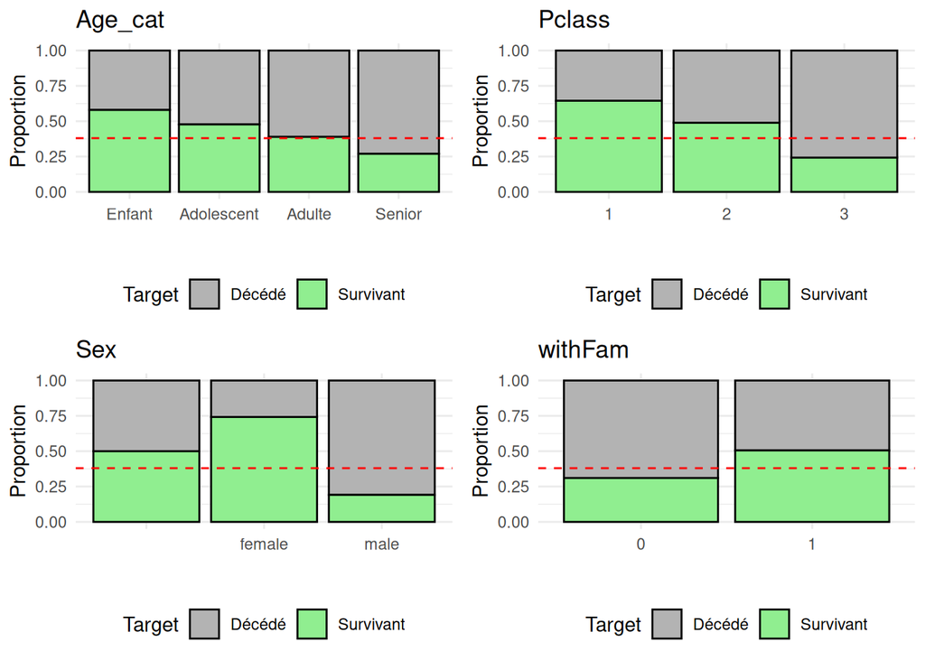

Proportion de survie par catégorie

```r
# Fonction pour générer les plots
plot_list = list()
for(col in names(qualitative_vars)){
  p = ggplot(data = data.frame(var = qualitative_vars[[col]], Target = target) %>% na.omit(),
             aes(x = var, fill = Target)) +
      geom_bar(position = "fill", color = "black") +
      scale_fill_manual(values = c("gray70", "lightgreen")) +
      theme_minimal() +
      geom_hline(yintercept = 0.38, linetype="dashed", color="red") + # Moyenne survie
      labs(title = col, x = "", y = "Proportion") +
      theme(legend.position = "bottom")
  plot_list[[col]] = p
}

grid.arrange(grobs = plot_list, ncol = 2)
```

**Conclusions majeures :**

1. **Sex :** Les femmes ont beaucoup plus survécu.
2. **Pclass :** La 1ère classe a un net avantage.
3. **Age_cat :** Les enfants ont été protégés.

## 4. Gestion des données manquantes

```r
colSums(is.na(data))
```

```
PassengerId    Survived      Pclass         Sex         Age       SibSp
          0           0           0           0         169           0
      Parch        Fare         Fam     withFam     Age_cat
          0           0           0           0         169
```

- **Qualitatives (ex: Cabin, Embarked)** : Créer une catégorie “Inconnu” ou imputer par le mode.
- **Quantitatives (ex: Age)** : Imputer par la médiane ou utiliser une régression basée sur le titre (Mr, Mrs, Master…).

## 5. Sauvegarde

Nous sauvegardons les données nettoyées pour le prochain TP.

```r
write.csv(data, "titanic_pre_processed.csv", row.names = FALSE)
write.csv(target, "titanic_pre_processed_target.csv", row.names = FALSE)
write.csv(quantitative_vars, "titanic_pre_processed_quantitative_vars.csv", row.names = FALSE)
write.csv(qualitative_vars, "titanic_pre_processed_qualitative_vars.csv", row.names = FALSE)
```